# MEDL_HW08

**Deep Learning for Mechanical Engineering**  
**Homework 08**  
**Due Thursday, 06/04/2020, 3:30 PM**

TA: Kangsan Lee and Namjeong Lee  
Instructor: Prof. Seungchul Lee  
http://iai.postech.ac.kr/  
Industrial AI Lab at POSTECH

- For your handwritten solution, scan or take a picture of them.
- For your code, only .ipynb file will be graded.
  - Please write your NAME and student ID on your .ipynb files. ex) KangsanLee_20202467_HW08.ipynb
- Please compress all the files to make a single .zip file
  - Please write your NAME and student ID on your .zip files. ex) NamjeongLee_20202467_HW08.zip
  - Submit it to LMS
- Do not submit a printed version of your code. It will not be graded.

# Problem 1: MNIST Digit Classification with Insufficient Data

In many real problems, lack of data is a critical issue. Especially, engineering problems rarely have fault data since they have to be collected when the system is abnoramlly operating. Thus, it is essential to train the model with a small data set. One possible method is the **transfer learning** that we learned in class.

In this problem, we are going to classify MNIST digit images with insufficient train data. First, we will train a CNN model with a small dataset. And then, we will train the same model but using transfer learning to compare both models.

For transfer learning, we will use the [EMNIST alphabet dataset](https://www.nist.gov/itl/products-and-services/emnist-dataset).

[Download alphabet dataset](https://www.dropbox.com/s/llmme9kvapgp71b/EMNIST_files.zip?dl=1)

```python
import numpy as np
import matplotlib.pyplot as plt
%matplotlib inline

import tensorflow as tf
from sklearn.model_selection import train_test_split
```

(1) Load MNIST dataset. To intentionally make data insufficient, set each digit to have around 50 data and print the number of each class.

```python
from tensorflow.examples.tutorials.mnist import input_data
# Your code here
```

[output not shown]

(2) Define a CNN model for MNIST.

```python
# Your code here
```

[output not shown]

(3) Train your model, plot train and test loss, and test your model. Since the model is trained with small dataset, testset accuracy might be low.

```
(0000/0250) loss_train: 2.168084, loss_test: 2.495427
(0012/0250) loss_train: 1.629037, loss_test: 1.821477
(0024/0250) loss_train: 0.674461, loss_test: 1.177563
(0036/0250) loss_train: 0.314553, loss_test: 1.060985
(0048/0250) loss_train: 0.109371, loss_test: 0.709971
(0060/0250) loss_train: 0.116191, loss_test: 1.032673
(0072/0250) loss_train: 0.120059, loss_test: 0.943529
(0084/0250) loss_train: 0.045524, loss_test: 1.179049
(0096/0250) loss_train: 0.029166, loss_test: 0.830295
(0108/0250) loss_train: 0.040678, loss_test: 0.757991
(0120/0250) loss_train: 0.017398, loss_test: 1.062695
(0132/0250) loss_train: 0.012111, loss_test: 0.879852
(0144/0250) loss_train: 0.010600, loss_test: 0.658549
(0156/0250) loss_train: 0.013083, loss_test: 1.142465
(0168/0250) loss_train: 0.014075, loss_test: 0.606477
(0180/0250) loss_train: 0.008061, loss_test: 0.989068
(0192/0250) loss_train: 0.002414, loss_test: 0.742902
(0204/0250) loss_train: 0.009107, loss_test: 1.206381
(0216/0250) loss_train: 0.004790, loss_test: 1.202949
(0228/0250) loss_train: 0.004224, loss_test: 1.251552
(0240/0250) loss_train: 0.004379, loss_test: 0.590910
```

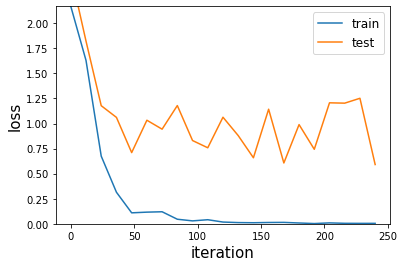

```
Accuracy_trainset : 100.0%
Accuracy_testset : 77.6%
```

```python
# Your code here
```

Now, we are going to apply the transfer learning. First, run the below cell to load the hand-written alphabet dataset.

```python
img_file = './data_files/Alphabet_Handwritten_1000_images.npy'
lbl_file = './data_files/Alphabet_Handwritten_1000_labels.npy'

x_total = (np.load(img_file)/255).astype(np.float32)
y_total = tf.keras.utils.to_categorical(np.load(lbl_file))

x_train, x_test, y_train, y_test = train_test_split(x_total, y_total, test_size=0.3, random_state=77)

print('Trainset shape:', x_train.shape, y_train.shape)
print('Testset shape:', x_test.shape, y_test.shape)

del x_total, y_total
```

```
Trainset shape: (18200, 784) (18200, 26)
Testset shape: (7800, 784) (7800, 26)
```

(4) Plot random images for each character.

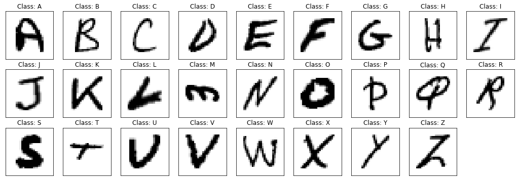

```python
# Your code here
```

(5) Initialize all weights, train the CNN model with EMNIST alphbet data, and test the model.

```
(0000/1000) loss_train: 3.159599, loss_test: 3.447819
(0050/1000) loss_train: 1.378981, loss_test: 1.479045
(0100/1000) loss_train: 0.565480, loss_test: 0.899779
(0150/1000) loss_train: 0.763321, loss_test: 0.489045
(0200/1000) loss_train: 0.556435, loss_test: 0.602914
(0250/1000) loss_train: 0.530005, loss_test: 0.520498
(0300/1000) loss_train: 0.331995, loss_test: 0.457293
(0350/1000) loss_train: 0.386386, loss_test: 0.215602
(0400/1000) loss_train: 0.295990, loss_test: 0.214385
(0450/1000) loss_train: 0.199767, loss_test: 0.328641
(0500/1000) loss_train: 0.325809, loss_test: 0.321964
(0550/1000) loss_train: 0.198189, loss_test: 0.112913
(0600/1000) loss_train: 0.164106, loss_test: 0.061221
(0650/1000) loss_train: 0.222403, loss_test: 0.341578
(0700/1000) loss_train: 0.161209, loss_test: 0.232594
(0750/1000) loss_train: 0.127776, loss_test: 0.206816
(0800/1000) loss_train: 0.117685, loss_test: 0.443886
(0850/1000) loss_train: 0.040783, loss_test: 0.118017
(0900/1000) loss_train: 0.252389, loss_test: 0.235753
(0950/1000) loss_train: 0.085184, loss_test: 0.216133
(1000/1000) loss_train: 0.083533, loss_test: 0.226429
```

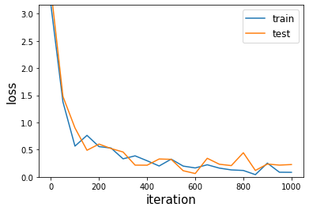

```
Accuracy_trainset : 96.0%
Accuracy_testset : 94.1%
```

```python
# Your code here
```

(6) Use the pre-trained model from EMNIST (source data) to conduct the transfer learning to a small set of MNIST (target data).

```
(0000/0750) loss_train: 6.584275, loss_test: 8.211966
(0037/0750) loss_train: 2.169972, loss_test: 2.648992
(0074/0750) loss_train: 0.647756, loss_test: 0.909337
(0111/0750) loss_train: 0.465946, loss_test: 1.049898
(0148/0750) loss_train: 0.393517, loss_test: 0.731707
(0185/0750) loss_train: 0.264389, loss_test: 0.623767
(0222/0750) loss_train: 0.178649, loss_test: 0.651361
(0259/0750) loss_train: 0.149973, loss_test: 0.312321
(0296/0750) loss_train: 0.248857, loss_test: 0.507758
(0333/0750) loss_train: 0.113966, loss_test: 0.263756
(0370/0750) loss_train: 0.111079, loss_test: 0.383000
(0407/0750) loss_train: 0.055119, loss_test: 0.382795
(0444/0750) loss_train: 0.144577, loss_test: 0.262818
(0481/0750) loss_train: 0.118108, loss_test: 0.815028
(0518/0750) loss_train: 0.053491, loss_test: 0.828900
(0555/0750) loss_train: 0.070866, loss_test: 0.260933
(0592/0750) loss_train: 0.079107, loss_test: 0.492517
(0629/0750) loss_train: 0.069175, loss_test: 0.375308
(0666/0750) loss_train: 0.034486, loss_test: 0.591680
(0703/0750) loss_train: 0.030975, loss_test: 0.354280
(0740/0750) loss_train: 0.090028, loss_test: 0.390115
```

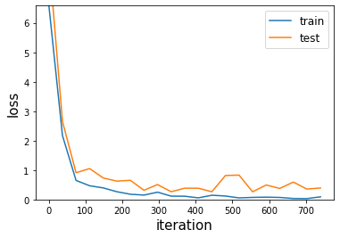

```
Accuracy_trainset : 99.4%
Accuracy_testset : 86.6%
```

```python
# Your code here
```